# Recipe Rating Analysis: Nutritional Values and Ingredients

### 4.2.5 Amount of ingredients per recipe

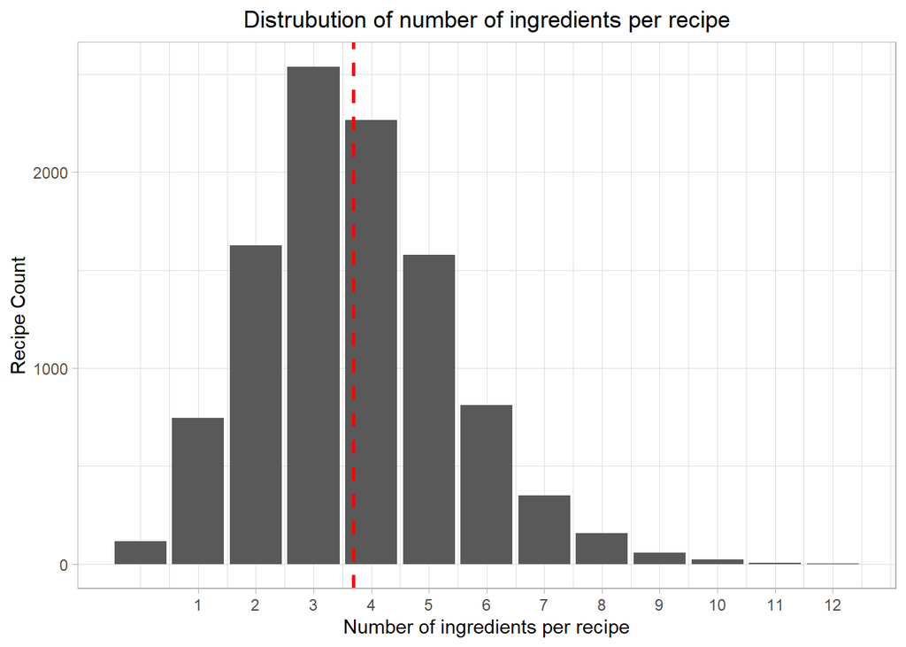

```r
#checking some stuff about the new ingredients table
ingredients_df_total %>%
  select(ID, title, total_ingredients) %>%
  ggplot(aes(x=total_ingredients)) +
  geom_bar() + geom_vline(aes(xintercept=mean(total_ingredients)),color="red", linetype="dashed", size=1)+
   scale_x_continuous(breaks = seq(1, 12, by = 1)) +
  labs(x="Number of ingredients per recipe", y = "Recipe Count", title = "Distrubution of number of ingredients per recipe")
```

```r
#we notice that 117 (no NAs and RAT0, and not duplicated) recipes have 0 ingredients, let's investigate why and how that's possible
(ingredients_df_total %>%
  filter(total_ingredients==0))

#let's pick recipe ID number 1183 which should have poppy and sesame seeds according to the title
recipes %>%
  filter(ID == 1183) %>%
  select_if(~ any(. == 1))
#we can see that only 3 variables are equal to 1 here
recipes %>%
  filter(ID == 365) %>%
  select_if(~ any(. == 1))

recipes %>%
  filter(ID == 1089) %>%
  select_if(~ any(. == 1))

#####
#QUESTION: do we want to keep those recipes?
#####


ingredients_df_total %>%
  filter(total_ingredients >10)
```

Besides the total amount of ingredients, let’s check the amount of ingredients per recipe for the top 3 categories in terms of ingredients frequency (i.e., vegetables, fruits, meats)

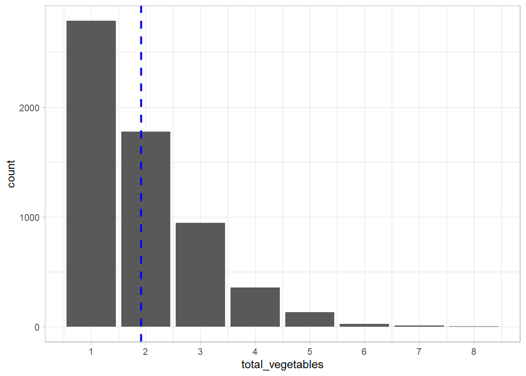

```r
ingredients_df_full %>%
  filter(vegetables_bin == 1) %>%
  select(ID, title, total_vegetables) %>%
  ggplot(aes(x=total_vegetables)) +
  scale_x_continuous(breaks = seq(1, 9, by = 1)) +
  geom_bar() + geom_vline(aes(xintercept=mean(total_vegetables)),color="blue", linetype="dashed", size=1)
```

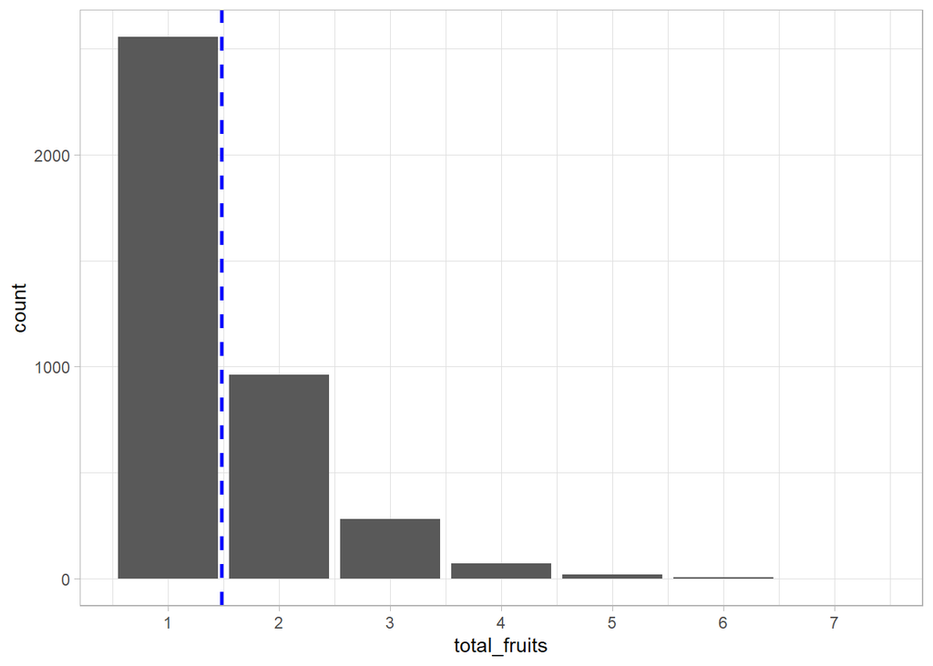

```r
ingredients_df_full %>%
  filter(fruits_bin == 1) %>%
  select(ID, title, total_fruits) %>%
  ggplot(aes(x=total_fruits)) +
  scale_x_continuous(breaks = seq(1, 9, by = 1)) +
  geom_bar() + geom_vline(aes(xintercept=mean(total_fruits)),color="blue", linetype="dashed", size=1)
```

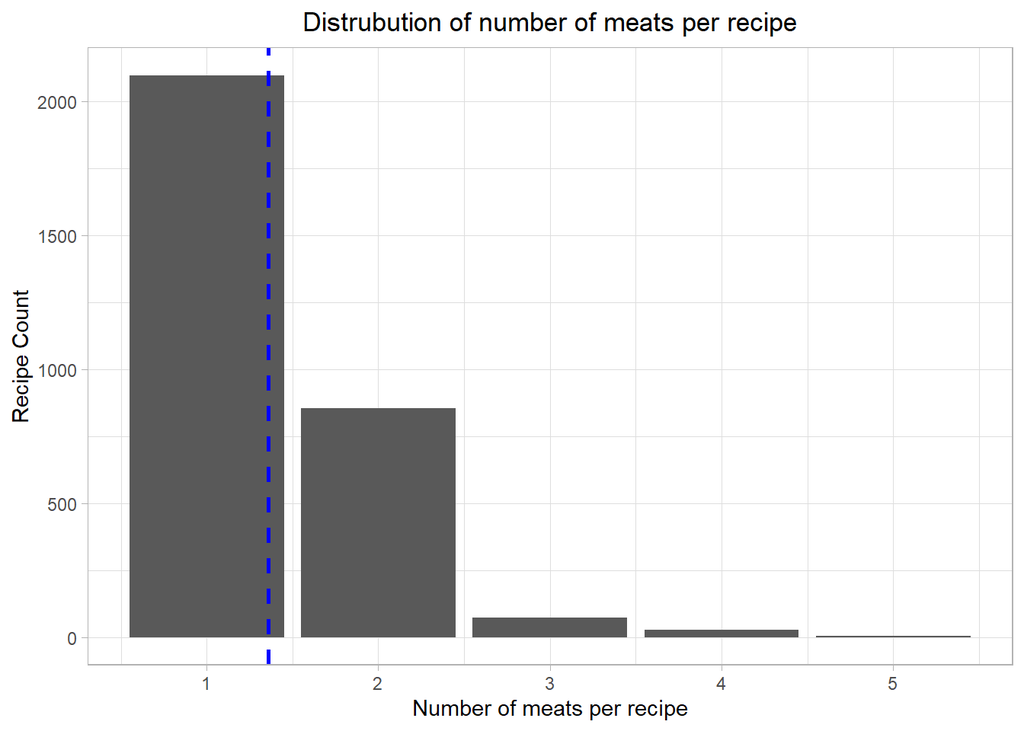

```r
# ingredients_df_full %>%
#   select(ID, title, total_meat) %>%
#   ggplot(aes(x=total_meat)) +
#   geom_bar() + geom_vline(aes(xintercept=mean(total_meat)),color="blue", linetype="dashed", size=1)+
#   labs(x="Number of meats per recipe", y = "Recipe Count", title = "Distrubution of number of meats per recipe")

#let's try to filter by recipes which contain meat to see if my functions work
ingredients_df_full %>%
  filter(meats_bin == 1) %>%
  select(ID, title, total_meat) %>%
  ggplot(aes(x=total_meat)) +
  geom_bar() + geom_vline(aes(xintercept=mean(total_meat)),color="blue", linetype="dashed", size=1)+
  labs(x="Number of meats per recipe", y = "Recipe Count", title = "Distrubution of number of meats per recipe")
```

```r
#why do we still have value in 0 meats --> it was because when creating the total meat column in ingredients_df_test I did not include the general meat category
```

## 4.3 Categories relative to rating

It’s hard to interpret the results clearly with so many rating, let’s try to reduce it to 2 category –> above 4, and below 4

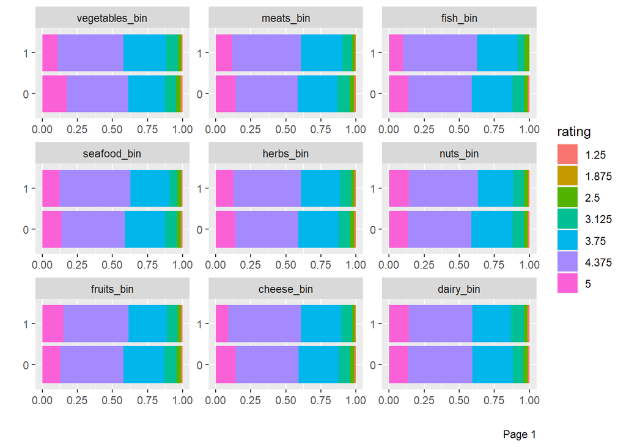

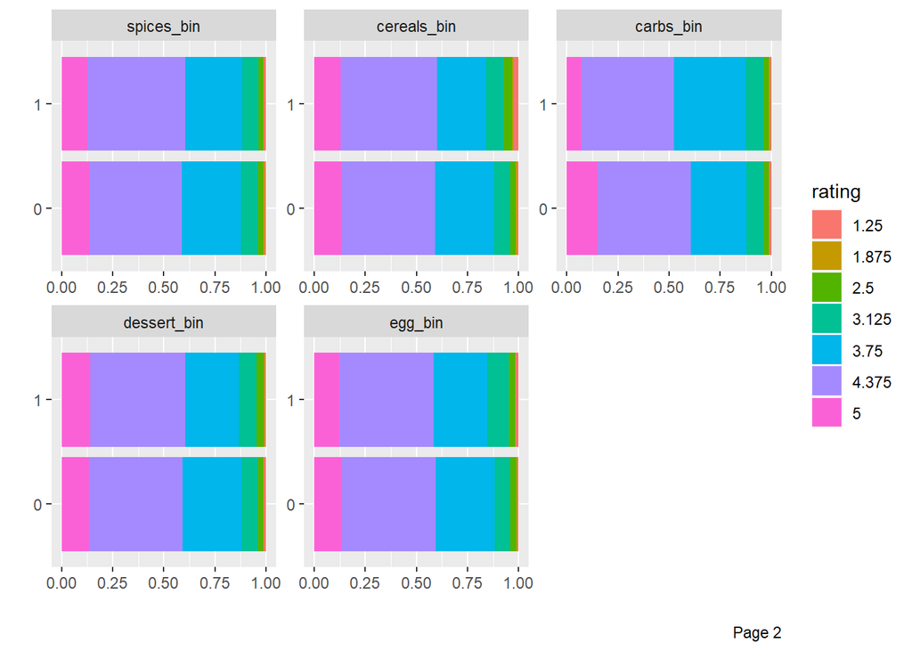

```r
ingredients_df_bin %>%
  select(contains("bin"), rating) %>%
  mutate(across(everything(), as.factor)) %>%
  plot_bar(by = "rating", order_bar = FALSE)
```

We not have only 2 categories: recipes with rating above 4 and recipes with ratings below 4. There is no clear relationship in those graphs either, and this confirms the correlation results that we have above.

If we look at vegetables for example, we can see that the proportion of recipes with ratings above 4 is higher for recipes containing no vegetables, when compared to recipes containing at least one vegetable.

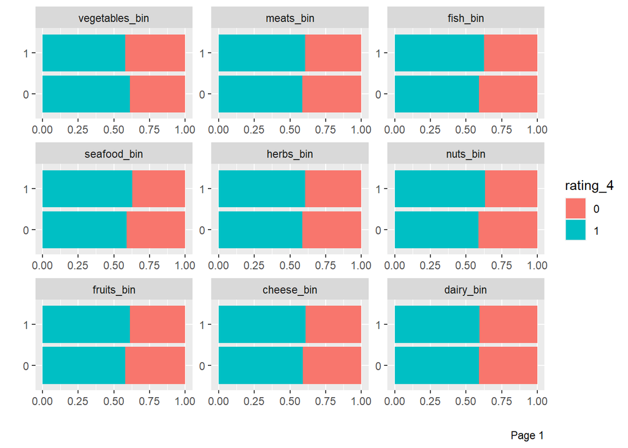

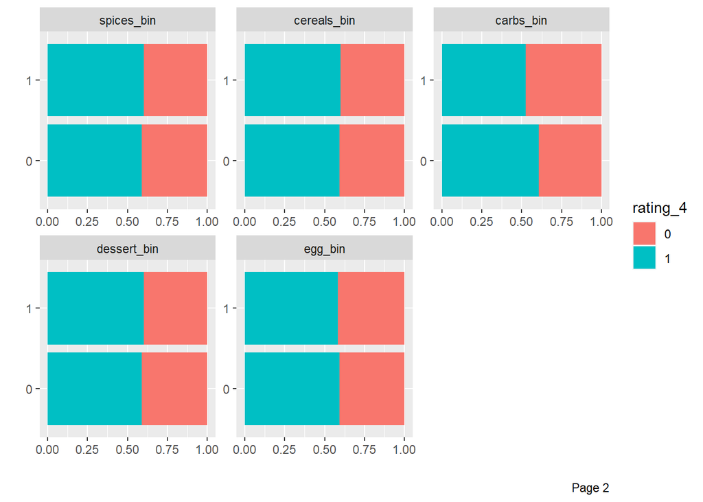

```r
ingredients_df_bin %>%
  select(contains("bin"), rating) %>%
  mutate(rating_4 = ifelse(rating>4, 1, 0), across(everything(), as.factor)) %>%
  select(-rating) %>%
  plot_bar(by = "rating_4", order_bar = FALSE)
```

# 5 Seasons and Recipe Type EDA

```r
#TO ADD WHEN COMPLETED
```

# 6 Mixed EDA - ingredients and nutritional value

```r
ingredients_df_full <- ingredients_df %>%
  mutate(total_ingredients = rowSums(select(., c(all_of(all_ingredients)))),
         total_meat = rowSums(select(., c(all_of(all_meats)))),
         total_vegetables = rowSums(select(., c(all_of(vegetables_vec))))
         )

recipes_select <- recipes %>%
  select(ID, title, rating, calories, protein, sodium, fat)

ingredients_select <- ingredients_df_full %>%
  select(ID, total_ingredients, total_meat, total_vegetables)

recipes_more <- recipes_select %>%
  left_join(ingredients_select,
           by=c('ID'))

ingredients_bin_select <- ingredients_df_bin %>%
  select(ID, contains("bin"))


recipes_full <- recipes_more %>%
  left_join(ingredients_bin_select,
           by=c('ID'))
```

## 6.1 Correlation between nutritional values and categories

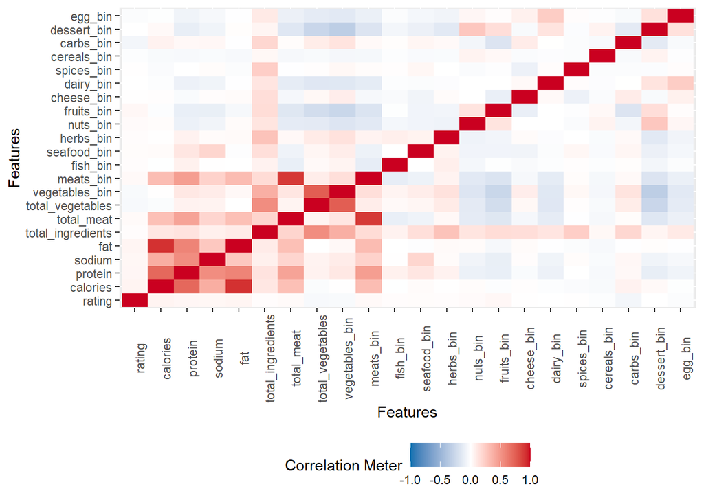

```r
recipes_full %>%
  select(-ID) %>%
  plot_correlation()
```

For instance we notice a positive correlation between proteins and meats_bin which includes all sorts of meat. Another visible positive correlation is the one between sodium and seafood_bin. We might also want to investigate the relationship between calories and carbs_bin.

## 6.2 Barplot and boxplot - Meat and Proteins

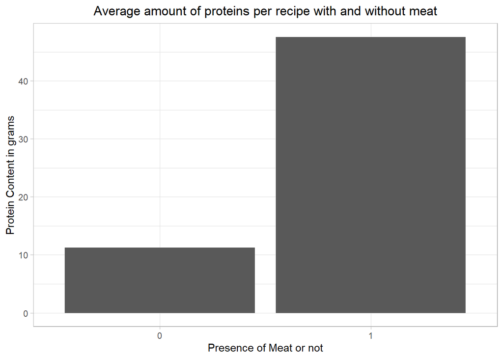

```r
# Barplot
recipes_full %>%
  ggplot(aes(x = factor(meats_bin), y = protein)) +
  stat_summary(fun.y = mean, geom = "bar") +
  ggtitle("Average amount of proteins per recipe with and without meat") +
  xlab("Presence of Meat or not") +
  ylab("Protein Content in grams")
```

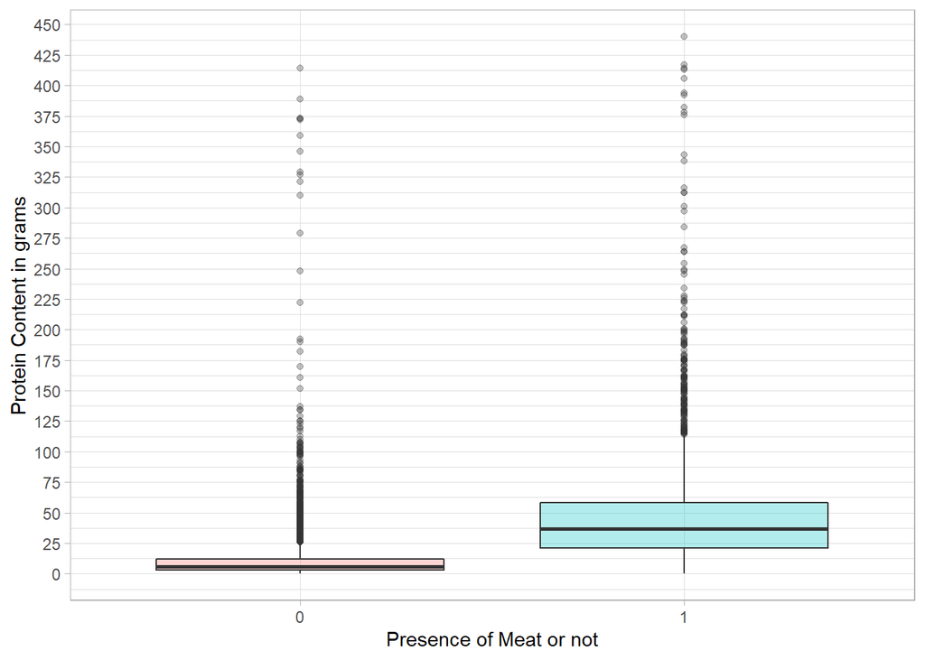

```r
# Boxplot
recipes_full %>%
  filter(protein < 450) %>%
  ggplot(aes(x=factor(meats_bin), y=protein, fill=factor(meats_bin))) +
  geom_boxplot(alpha=0.3) +
  scale_y_continuous(breaks=seq(0,7000,25)) +
  xlab("Presence of Meat or not") +
  ylab("Protein Content in grams") +
  theme(legend.position="none")
```

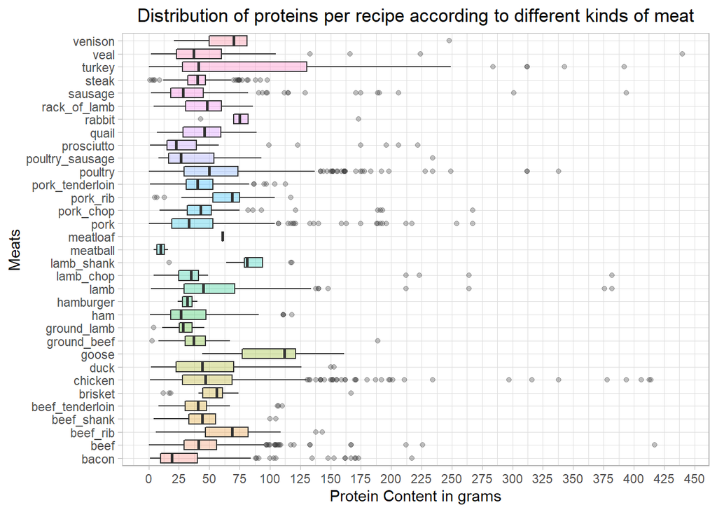

```r
# Boxplots per different kinds of meat
recipes_general <- recipes_full %>%
  select(ID) %>%
  left_join(recipes,
           by=c('ID'))

recipes_meat <- recipes_general %>%
  select(ID, title, rating, calories, protein, fat, sodium, all_of(all_meats))

recipes_meat <- recipes_meat %>%
  pivot_longer(cols=c("beef", "beef_rib", "beef_shank", "beef_tenderloin", "brisket", "ground_beef", "hamburger", "veal", "bacon", "ham", "pork", "pork_chop", "pork_rib", "pork_tenderloin", "prosciutto", "ground_lamb", "lamb", "lamb_chop", "lamb_shank", "rack_of_lamb", "chicken", "duck", "goose", "poultry", "poultry_sausage", "quail", "turkey", "meatball", "meatloaf", "rabbit", "sausage", "steak", "venison" ),
                    names_to='meats',
                    values_to='yes_or_no') %>%
  filter(yes_or_no == 1)

recipes_meat %>%
  filter(protein < 450) %>%
  ggplot(aes(x=meats, y=protein, fill=meats)) +
  geom_boxplot(alpha=0.3) +
  scale_y_continuous(breaks=seq(0,7000,25)) +
  coord_flip() +
  ggtitle("Distribution of proteins per recipe according to different kinds of meat") +
  xlab("Meats") +
  ylab("Protein Content in grams") +
  theme(legend.position="none")
```

```r
# Here we want to show which kinds of meat specifically have a high level of proteins
```

## 6.3 Barplot and boxplot - Seafood and Sodium

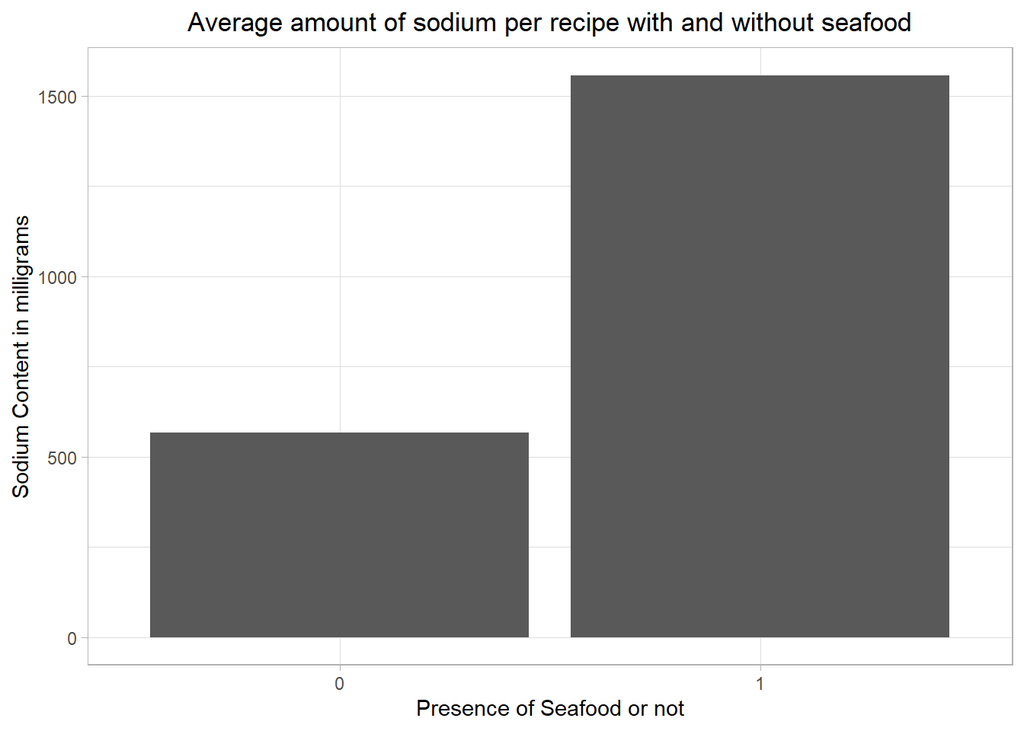

```r
# Seafood and sodium
recipes_full %>%
  ggplot(aes(x = factor(seafood_bin), y = sodium)) +
  stat_summary(fun.y = mean, geom = "bar") +
  ggtitle("Average amount of sodium per recipe with and without seafood")  +
  xlab("Presence of Seafood or not") +
  ylab("Sodium Content in milligrams")
```

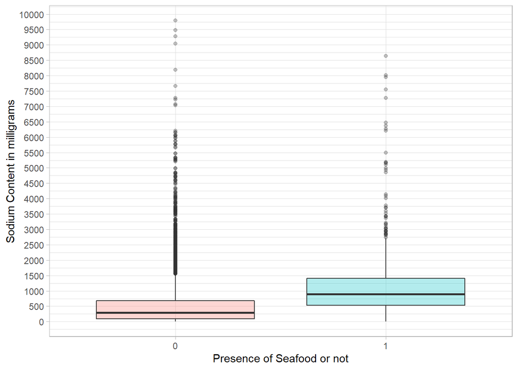

```r
# Boxplot
recipes_full %>%
  filter(sodium < 10000) %>%
  ggplot(aes(x=factor(seafood_bin), y=sodium, fill=factor(seafood_bin))) +
  geom_boxplot(alpha=0.3) +
  scale_y_continuous(breaks=seq(0,30000,500)) +
  xlab("Presence of Seafood or not") +
  ylab("Sodium Content in milligrams") +
  theme(legend.position="none")
```

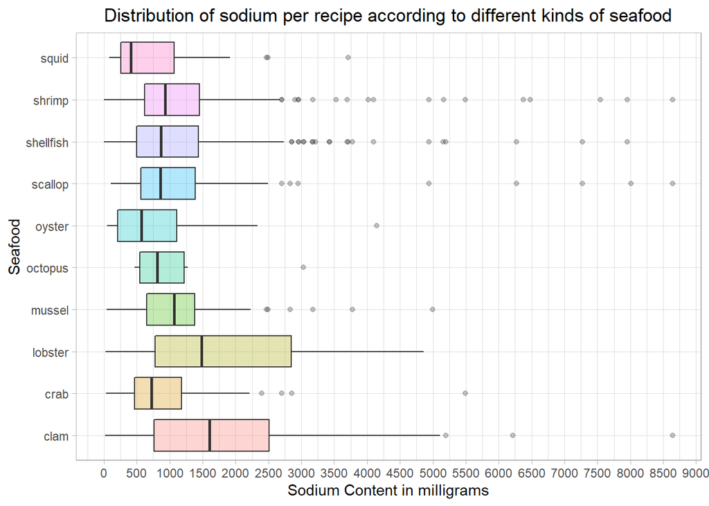

```r
# Boxplots per different kinds of seafood

recipes_seafood <- recipes_general %>%
  select(ID, title, rating, calories, protein, fat, sodium, all_of(seafood_vec))

recipes_seafood <- recipes_seafood %>%
  pivot_longer(cols=c("clam", "crab", "lobster", "mussel", "octopus", "oyster", "scallop", "shellfish", "shrimp", "squid" ),
                    names_to='seafoods',
                    values_to='yes_or_no') %>%
  filter(yes_or_no == 1)

recipes_seafood %>%
  filter(sodium < 10000) %>%
  ggplot(aes(x=seafoods, y=sodium, fill=seafoods)) +
  geom_boxplot(alpha=0.3) +
  scale_y_continuous(breaks=seq(0,30000,500)) +
  coord_flip() +
  ggtitle("Distribution of sodium per recipe according to different kinds of seafood") +
  xlab("Seafood") +
  ylab("Sodium Content in milligrams") +
  theme(legend.position="none")
```

```r
# Here we want to show which kinds of seafood specifically have a high level of sodium
```

## 6.4 Barplot and boxplot - Carbs and Calories

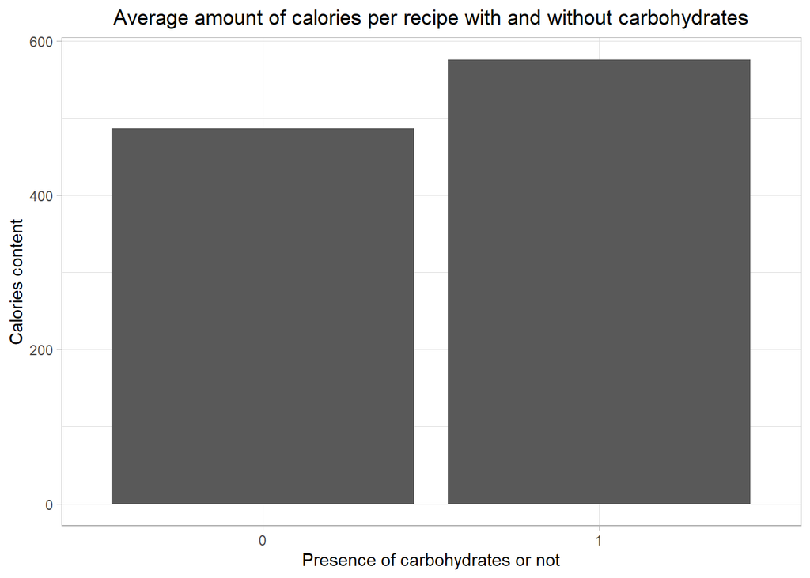

```r
# Carbs and calories
recipes_full %>%
  ggplot(aes(x = factor(carbs_bin), y = calories)) +
  stat_summary(fun.y = mean, geom = "bar") +
  ggtitle("Average amount of calories per recipe with and without carbohydrates") +
  xlab("Presence of carbohydrates or not") +
  ylab("Calories content")
```

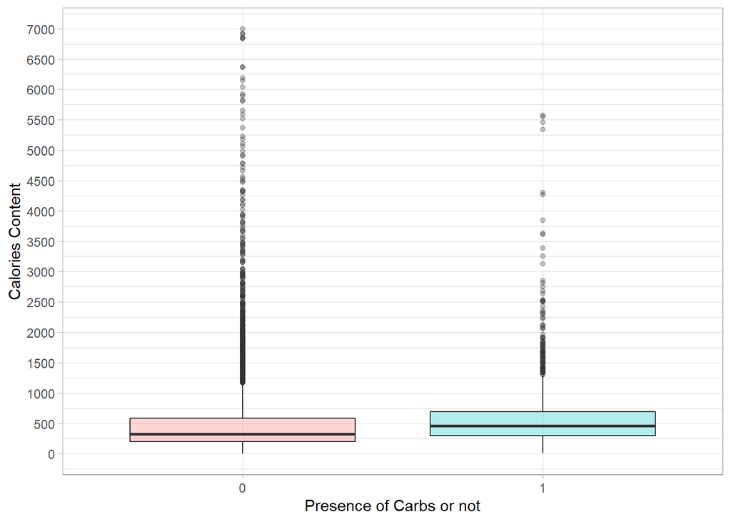

```r
# Afterwards we would also want to show which kinds of carbs specifically have a high number of calories


# Boxplot
recipes_full %>%
  ggplot(aes(x=factor(carbs_bin), y=calories, fill=factor(carbs_bin))) +
  geom_boxplot(alpha=0.3) +
  scale_y_continuous(breaks=seq(0,7000,500)) +
  xlab("Presence of Carbs or not") +
  ylab("Calories Content") +
  theme(legend.position="none")
```

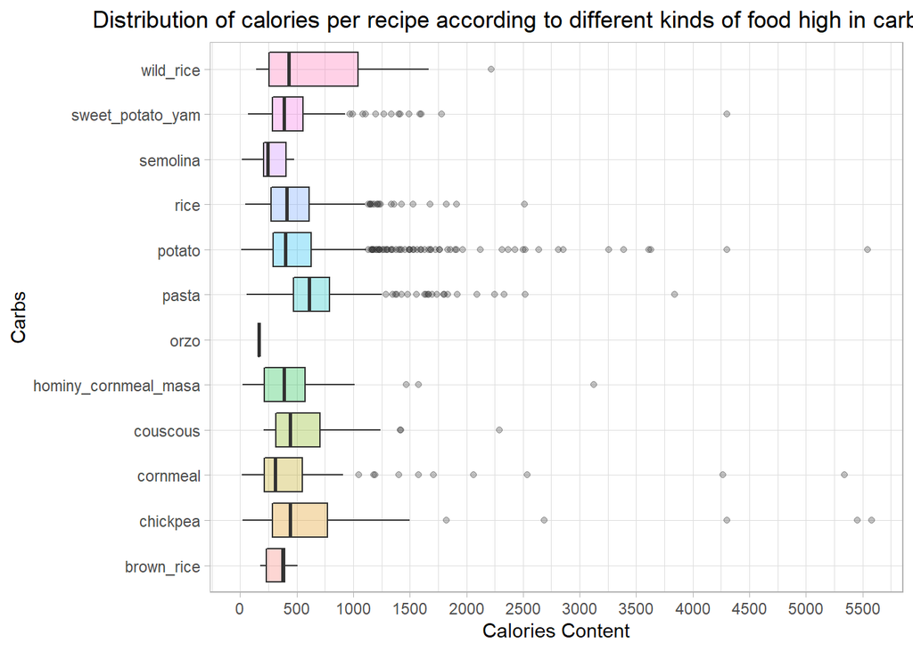

```r
# Boxplots per different kinds of carbs
recipes_carbs <- recipes_general %>%
  select(ID, title, rating, calories, protein, fat, sodium, all_of(carbs_vec))

recipes_carbs <- recipes_carbs %>%
  pivot_longer(cols=c("brown_rice", "chickpea", "cornmeal", "couscous", "hominy_cornmeal_masa", "orzo", "pasta", "potato", "rice", "semolina", "sweet_potato_yam", "wild_rice"),
                    names_to='carbs',
                    values_to='yes_or_no') %>%
  filter(yes_or_no == 1)

recipes_carbs %>%
  filter(sodium < 10000) %>%
  ggplot(aes(x=carbs, y=calories, fill=carbs)) +
  geom_boxplot(alpha=0.3) +
  scale_y_continuous(breaks=seq(0,7000,500)) +
  coord_flip() +
  ggtitle("Distribution of calories per recipe according to different kinds of food high in carbohydrates") +
  xlab("Carbs") +
  ylab("Calories Content") +
  theme(legend.position="none")
```

```r
# Here we want to show which kinds of food high in carbs specifically have a high level of calories
```

# 7 Supervised Learning

# 8 Unsupervised Learning